# **Capstone project: Providing data-driven suggestions for HR**

## Description and deliverables

This capstone project is an opportunity for you to analyze a dataset and build predictive models that can provide insights to the Human Resources (HR) department of a large consulting firm.

Upon completion, you will have two artifacts that you would be able to present to future employers. One is a brief one-page summary of this project that you would present to external stakeholders as the data professional in Salifort Motors. The other is a complete code notebook provided here. Please consider your prior course work and select one way to achieve this given project question. Either use a regression model or machine learning model to predict whether or not an employee will leave the company. The exemplar following this actiivty shows both approaches, but you only need to do one.

In your deliverables, you will include the model evaluation (and interpretation if applicable), a data visualization(s) of your choice that is directly related to the question you ask, ethical considerations, and the resources you used to troubleshoot and find answers or solutions.

# **PACE stages**

## **Pace: Plan**

Consider the questions in your PACE Strategy Document to reflect on the Plan stage.

In this stage, consider the following:

### Understand the business scenario and problem

The HR department at Salifort Motors wants to take some initiatives to improve employee satisfaction levels at the company. They collected data from employees, but now they don’t know what to do with it. They refer to you as a data analytics professional and ask you to provide data-driven suggestions based on your understanding of the data. They have the following question: what’s likely to make the employee leave the company?

Your goals in this project are to analyze the data collected by the HR department and to build a model that predicts whether or not an employee will leave the company.

If you can predict employees likely to quit, it might be possible to identify factors that contribute to their leaving. Because it is time-consuming and expensive to find, interview, and hire new employees, increasing employee retention will be beneficial to the company.

### Familiarize yourself with the HR dataset

The dataset that you'll be using in this lab contains 15,000 rows and 10 columns for the variables listed below.

**Note:** you don't need to download any data to complete this lab. For more information about the data, refer to its source on [Kaggle](https://www.kaggle.com/datasets/mfaisalqureshi/hr-analytics-and-job-prediction?select=HR_comma_sep.csv).

💭

### Reflect on these questions as you complete the plan stage.

- Who are your stakeholders for this project?
- What are you trying to solve or accomplish?
- What are your initial observations when you explore the data?
- What resources do you find yourself using as you complete this stage? (Make sure to include the links.)
- Do you have any ethical considerations in this stage?

## Step 1. Imports

- Import packages
- Load dataset

### Import packages

```python
import pandas as pd
import numpy as np
pd.set_option('display.max_columns', None)

import matplotlib.pyplot as plt
import seaborn as sns

from sklearn.ensemble import RandomForestClassifier
from sklearn.model_selection import GridSearchCV, train_test_split
from sklearn.metrics import accuracy_score, precision_score, recall_score,\
f1_score, confusion_matrix, ConfusionMatrixDisplay
from sklearn.utils import resample
from sklearn.metrics import classification_report

import xgboost as xgb
from xgboost import XGBClassifier
from xgboost import plot_importance
```

### Load dataset

`Pandas` is used to read a dataset called **`HR_capstone_dataset.csv`.** As shown in this cell, the dataset has been automatically loaded in for you. You do not need to download the .csv file, or provide more code, in order to access the dataset and proceed with this lab. Please continue with this activity by completing the following instructions.

```python
# RUN THIS CELL TO IMPORT YOUR DATA.

# Load dataset into a dataframe
### YOUR CODE HERE ###
df = pd.read_csv("HR_capstone_dataset.csv")


# Display first few rows of the dataframe
### YOUR CODE HERE ###
df.head()
```

|  | satisfaction_level | last_evaluation | number_project | average_montly_hours | time_spend_company | Work_accident | left | promotion_last_5years | Department | salary |
| --- | --- | --- | --- | --- | --- | --- | --- | --- | --- | --- |
| 0 | 0.38 | 0.53 | 2 | 157 | 3 | 0 | 1 | 0 | sales | low |
| 1 | 0.80 | 0.86 | 5 | 262 | 6 | 0 | 1 | 0 | sales | medium |
| 2 | 0.11 | 0.88 | 7 | 272 | 4 | 0 | 1 | 0 | sales | medium |
| 3 | 0.72 | 0.87 | 5 | 223 | 5 | 0 | 1 | 0 | sales | low |
| 4 | 0.37 | 0.52 | 2 | 159 | 3 | 0 | 1 | 0 | sales | low |

## Step 2. Data Exploration (Initial EDA and data cleaning)

- Understand your variables
- Clean your dataset (missing data, redundant data, outliers)

### Gather basic information about the data

```python
# Gather basic information about the data
### YOUR CODE HERE ###
print(df.shape)
print(df.info())
```

```
(14999, 10)
<class 'pandas.core.frame.DataFrame'>
RangeIndex: 14999 entries, 0 to 14998
Data columns (total 10 columns):
 #   Column                 Non-Null Count  Dtype
---  ------                 --------------  -----
 0   satisfaction_level     14999 non-null  float64
 1   last_evaluation        14999 non-null  float64
 2   number_project         14999 non-null  int64
 3   average_montly_hours   14999 non-null  int64
 4   time_spend_company     14999 non-null  int64
 5   Work_accident          14999 non-null  int64
 6   left                   14999 non-null  int64
 7   promotion_last_5years  14999 non-null  int64
 8   Department             14999 non-null  object
 9   salary                 14999 non-null  object
dtypes: float64(2), int64(6), object(2)
memory usage: 1.1+ MB
None
```

### Gather descriptive statistics about the data

```python
# Gather descriptive statistics about the data
### YOUR CODE HERE ###
df.describe()
```

|  | satisfaction_level | last_evaluation | number_project | average_montly_hours | time_spend_company | Work_accident | left | promotion_last_5years |
| --- | --- | --- | --- | --- | --- | --- | --- | --- |
| count | 14999.000000 | 14999.000000 | 14999.000000 | 14999.000000 | 14999.000000 | 14999.000000 | 14999.000000 | 14999.000000 |
| mean | 0.612834 | 0.716102 | 3.803054 | 201.050337 | 3.498233 | 0.144610 | 0.238083 | 0.021268 |
| std | 0.248631 | 0.171169 | 1.232592 | 49.943099 | 1.460136 | 0.351719 | 0.425924 | 0.144281 |
| min | 0.090000 | 0.360000 | 2.000000 | 96.000000 | 2.000000 | 0.000000 | 0.000000 | 0.000000 |
| 25% | 0.440000 | 0.560000 | 3.000000 | 156.000000 | 3.000000 | 0.000000 | 0.000000 | 0.000000 |
| 50% | 0.640000 | 0.720000 | 4.000000 | 200.000000 | 3.000000 | 0.000000 | 0.000000 | 0.000000 |
| 75% | 0.820000 | 0.870000 | 5.000000 | 245.000000 | 4.000000 | 0.000000 | 0.000000 | 0.000000 |
| max | 1.000000 | 1.000000 | 7.000000 | 310.000000 | 10.000000 | 1.000000 | 1.000000 | 1.000000 |

### Rename columns

As a data cleaning step, rename the columns as needed. Standardize the column names so that they are all in `snake_case`, correct any column names that are misspelled, and make column names more concise as needed.

```python
# Display all column names
### YOUR CODE HERE ###
df.columns
```

```
Index(['satisfaction_level', 'last_evaluation', 'number_project',
       'average_montly_hours', 'time_spend_company', 'Work_accident', 'left',
       'promotion_last_5years', 'Department', 'salary'],
      dtype='object')
```

```python
# Rename columns as needed
### YOUR CODE HERE ###
df = df.rename(columns={'Work_accident': 'work_accident', 'Department': 'department', 'time_spend_company': 'years_with_company',
                   'left': 'left_company', 'average_montly_hours': 'average_monthly_hours',
                   'last_evaluation': 'performance_review_score', 'number_project': 'number_projects'})

# Display all column names after the update
### YOUR CODE HERE ###
df.columns
```

```
Index(['satisfaction_level', 'performance_review_score', 'number_projects',
       'average_monthly_hours', 'years_with_company', 'work_accident',
       'left_company', 'promotion_last_5years', 'department', 'salary'],
      dtype='object')
```

### Check missing values

Check for any missing values in the data.

```python
# Check for missing values
### YOUR CODE HERE ###
df.isna().sum()
```

```
satisfaction_level          0
performance_review_score    0
number_projects             0
average_monthly_hours       0
years_with_company          0
work_accident               0
left_company                0
promotion_last_5years       0
department                  0
salary                      0
dtype: int64
```

### Check duplicates

Check for any duplicate entries in the data.

```python
# Check for duplicates
### YOUR CODE HERE ###
df.duplicated()
```

```
0        False
1        False
2        False
3        False
4        False
         ...
14994     True
14995     True
14996     True
14997     True
14998     True
Length: 14999, dtype: bool
```

```python
# Inspect some rows containing duplicates as needed
### YOUR CODE HERE ###
df[df.duplicated()].head()
```

|  | satisfaction_level | performance_review_score | number_projects | average_monthly_hours | years_with_company | work_accident | left_company | promotion_last_5years | department | salary |
| --- | --- | --- | --- | --- | --- | --- | --- | --- | --- | --- |
| 396 | 0.46 | 0.57 | 2 | 139 | 3 | 0 | 1 | 0 | sales | low |
| 866 | 0.41 | 0.46 | 2 | 128 | 3 | 0 | 1 | 0 | accounting | low |
| 1317 | 0.37 | 0.51 | 2 | 127 | 3 | 0 | 1 | 0 | sales | medium |
| 1368 | 0.41 | 0.52 | 2 | 132 | 3 | 0 | 1 | 0 | RandD | low |
| 1461 | 0.42 | 0.53 | 2 | 142 | 3 | 0 | 1 | 0 | sales | low |

```python
# Drop duplicates and save resulting dataframe in a new variable as needed
### YOUR CODE HERE ###

df_subset = df.drop_duplicates()
# Display first few rows of new dataframe as needed
### YOUR CODE HERE ###
print(df[df.duplicated()].shape)
print(df_subset.shape)
```

```
(3008, 10)
(11991, 10)
```

### Check outliers

Check for outliers in the data.

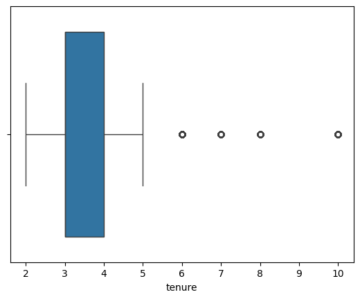

```python
# Create a boxplot to visualize distribution of `tenure` and detect any outliers
### YOUR CODE HERE ###

df_subset = df_subset.rename(columns={'years_with_company': 'tenure'})
sns.boxplot(x=df_subset['tenure'])
```

```python
# Determine the number of rows containing outliers
### YOUR CODE HERE ###

Q1 = df_subset['tenure'].quantile(0.25)
Q3 = df_subset['tenure'].quantile(0.75)

IQR = Q3 - Q1
outlier_threshold = IQR * 1.5

lower_bound = Q1 - outlier_threshold
upper_bound = Q3 + outlier_threshold

outliers = (df_subset['tenure'] < lower_bound) | (df_subset['tenure'] > upper_bound)

df_subset[outliers].shape[0]
```

```
824
```

```python
df_subset.describe()
```

|  | satisfaction_level | performance_review_score | number_projects | average_monthly_hours | tenure | work_accident | left_company | promotion_last_5years |
| --- | --- | --- | --- | --- | --- | --- | --- | --- |
| count | 11991.000000 | 11991.000000 | 11991.000000 | 11991.000000 | 11991.000000 | 11991.000000 | 11991.000000 | 11991.000000 |
| mean | 0.629658 | 0.716683 | 3.802852 | 200.473522 | 3.364857 | 0.154282 | 0.166041 | 0.016929 |
| std | 0.241070 | 0.168343 | 1.163238 | 48.727813 | 1.330240 | 0.361234 | 0.372133 | 0.129012 |
| min | 0.090000 | 0.360000 | 2.000000 | 96.000000 | 2.000000 | 0.000000 | 0.000000 | 0.000000 |
| 25% | 0.480000 | 0.570000 | 3.000000 | 157.000000 | 3.000000 | 0.000000 | 0.000000 | 0.000000 |
| 50% | 0.660000 | 0.720000 | 4.000000 | 200.000000 | 3.000000 | 0.000000 | 0.000000 | 0.000000 |
| 75% | 0.820000 | 0.860000 | 5.000000 | 243.000000 | 4.000000 | 0.000000 | 0.000000 | 0.000000 |
| max | 1.000000 | 1.000000 | 7.000000 | 310.000000 | 10.000000 | 1.000000 | 1.000000 | 1.000000 |

Certain types of models are more sensitive to outliers than others. When you get to the stage of building your model, consider whether to remove outliers, based on the type of model you decide to use.

# pAce: Analyze Stage

- Perform EDA (analyze relationships between variables)

💭

## Step 2. Data Exploration (Continue EDA)

Begin by understanding how many employees left and what percentage of all employees this figure represents.

```python
# Get numbers of people who left vs. stayed
### YOUR CODE HERE ###
df_subset['left_company'].value_counts()

# Get percentages of people who left vs. stayed
### YOUR CODE HERE ###
left = df_subset['left_company'].value_counts()[1]
stayed = df_subset['left_company'].value_counts()[0]

percentage_left = round((left/(left+stayed))*100,2)
percentage_stayed = round((stayed/(left+stayed))*100,2)

print(f'Percentage of people that left: {percentage_left}\n Percentage of people that stayed: {percentage_stayed}')
```

```
Percentage of people that left: 16.6
 Percentage of people that stayed: 83.4
```

### Data visualizations

Now, examine variables that you're interested in, and create plots to visualize relationships between variables in the data.

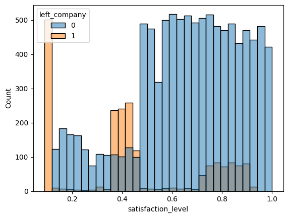

```python
# Create a plot as needed
### YOUR CODE HERE ###
sns.histplot(x=df_subset['satisfaction_level'], hue=df_subset['left_company'])
```

```python
df_subset[df_subset['number_projects']==7].shape
```

```
(145, 10)
```

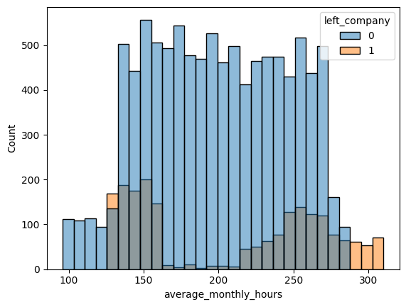

```python
# Create a plot as needed
### YOUR CODE HERE ###
sns.histplot(x=df_subset['average_monthly_hours'], hue=df_subset['left_company'])
```

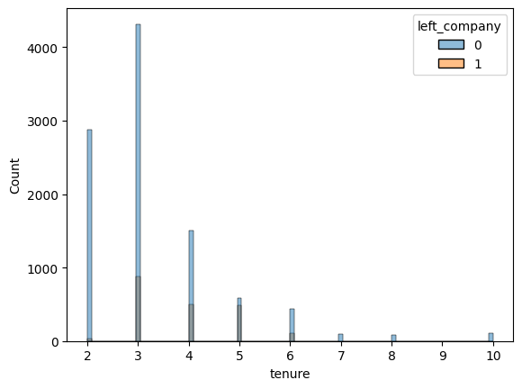

```python
# Create a plot as needed
### YOUR CODE HERE ###
sns.histplot(x=df_subset['tenure'], hue=df_subset['left_company'])
```

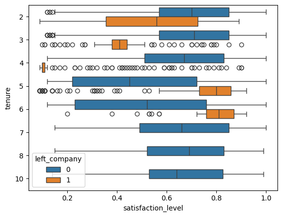

```python
# Create boxplot showing distributions of `satisfaction_level` by tenure, comparing employees who stayed versus those who left
sns.boxplot(data=df_subset, x='satisfaction_level', y='tenure', hue='left_company')
```

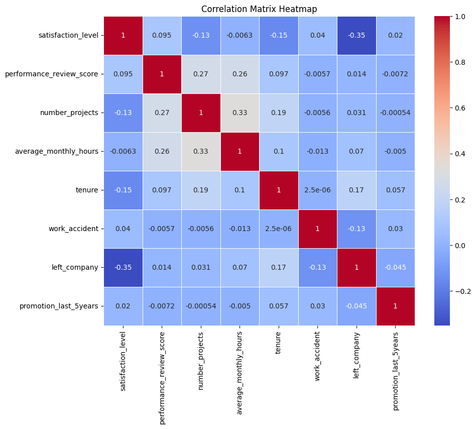

```python
# exclude non-numeric columns from the correlation matrix
numeric_columns = df_subset.select_dtypes(include=['number'])

# calculate correlation matrix
corr_matrix = numeric_columns.corr()

plt.figure(figsize=(10, 8))
sns.heatmap(corr_matrix, annot=True, cmap='coolwarm', linewidths=0.5)
plt.title('Correlation Matrix Heatmap')
plt.show()
```

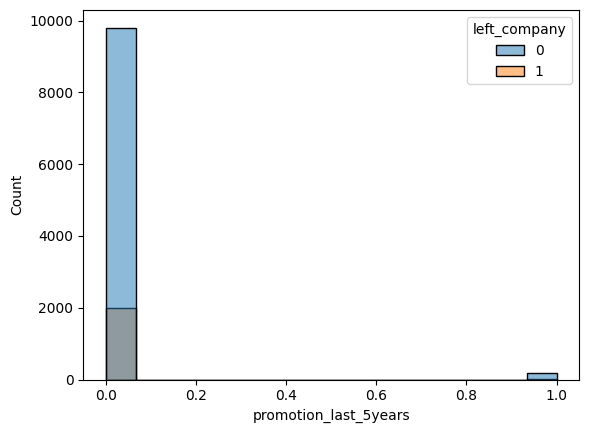

```python
# Create a plot as needed
### YOUR CODE HERE ###
sns.histplot(x=df_subset['promotion_last_5years'], hue=df_subset['left_company'])
```

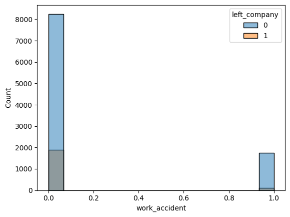

```python
# Create a plot as needed
### YOUR CODE HERE ###
sns.histplot(x=df_subset['work_accident'], hue=df_subset['left_company'])
```

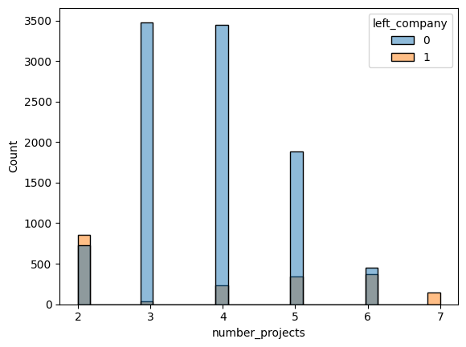

```python
# Create a plot as needed
### YOUR CODE HERE ###
sns.histplot(x=df_subset['number_projects'], hue=df_subset['left_company'])
```

```python
# Upsampling dataset
### YOUR CODE HERE ###

# create subsets of majority class and minority class
data_majority = df_subset[df_subset["left_company"] == 0]
data_minority = df_subset[df_subset["left_company"] == 1]

# upsample minority class
data_minority_upsampled = resample(data_minority, replace=True, n_samples=len(data_majority), random_state=0)
data_upsampled = pd.concat([data_majority, data_minority_upsampled]).reset_index(drop=True)

# verify the dataset is balanced
data_upsampled["left_company"].value_counts()
```

```
left_company
0    10000
1    10000
Name: count, dtype: int64
```

```python
data_upsampled.head()
```

|  | satisfaction_level | performance_review_score | number_projects | average_monthly_hours | tenure | work_accident | left_company | promotion_last_5years | department | salary |
| --- | --- | --- | --- | --- | --- | --- | --- | --- | --- | --- |
| 0 | 0.58 | 0.74 | 4 | 215 | 3 | 0 | 0 | 0 | sales | low |
| 1 | 0.82 | 0.67 | 2 | 202 | 3 | 0 | 0 | 0 | sales | low |
| 2 | 0.45 | 0.69 | 5 | 193 | 3 | 0 | 0 | 0 | sales | low |
| 3 | 0.78 | 0.82 | 5 | 247 | 3 | 0 | 0 | 0 | sales | low |
| 4 | 0.49 | 0.60 | 3 | 214 | 2 | 0 | 0 | 0 | sales | low |

```python
data_upsampled_encoded = pd.get_dummies(data_upsampled, drop_first=True)
```

```python
data_upsampled_encoded.head()
```

|  | satisfaction_level | performance_review_score | number_projects | average_monthly_hours | tenure | work_accident | left_company | promotion_last_5years | department_RandD | department_accounting | department_hr | department_management | department_marketing | department_product_mng | department_sales | department_support | department_technical | salary_low | salary_medium |
| --- | --- | --- | --- | --- | --- | --- | --- | --- | --- | --- | --- | --- | --- | --- | --- | --- | --- | --- | --- |
| 0 | 0.58 | 0.74 | 4 | 215 | 3 | 0 | 0 | 0 | False | False | False | False | False | False | True | False | False | True | False |
| 1 | 0.82 | 0.67 | 2 | 202 | 3 | 0 | 0 | 0 | False | False | False | False | False | False | True | False | False | True | False |
| 2 | 0.45 | 0.69 | 5 | 193 | 3 | 0 | 0 | 0 | False | False | False | False | False | False | True | False | False | True | False |
| 3 | 0.78 | 0.82 | 5 | 247 | 3 | 0 | 0 | 0 | False | False | False | False | False | False | True | False | False | True | False |
| 4 | 0.49 | 0.60 | 3 | 214 | 2 | 0 | 0 | 0 | False | False | False | False | False | False | True | False | False | True | False |

### Insights

# paCe: Construct Stage

- Determine which models are most appropriate
- Construct the model
- Confirm model assumptions
- Evaluate model results to determine how well your model fits the data

🔎

## Recall model assumptions

**Logistic Regression model assumptions**

- Outcome variable is categorical
- Observations are independent of each other
- No severe multicollinearity among X variables
- No extreme outliers
- Linear relationship between each X variable and the logit of the outcome variable
- Sufficiently large sample size

💭

### Reflect on these questions as you complete the constructing stage.

- Do you notice anything odd?
- Which independent variables did you choose for the model and why?
- Are each of the assumptions met?
- How well does your model fit the data?
- Can you improve it? Is there anything you would change about the model?
- What resources do you find yourself using as you complete this stage? (Make sure to include the links.)
- Do you have any ethical considerations in this stage?
- I do not notice anything odd.
- I chose to include all of the available variables as independent variables. They all seemed like they would have at least some moderate predicting ability.
- Yes. The features are independent, there is a sufficient sample size and the dataset has been cleaned.
- My model fits the data extremely well. Every scoring metric scored 0.99 except for recall which was 0.98.
- Given how well the model fit the data I do not think I can improve it. I would not change anything about my model.
- I used previous labs in this course as well as the glossaries that are included in the courses.
- I do not have any more ethical considerations compared to the last phase at this stage.

## Step 3. Model Building, Step 4. Results and Evaluation

- Fit a model that predicts the outcome variable using two or more independent variables
- Check model assumptions
- Evaluate the model

### Identify the type of prediction task.

The type of prediction task that this project requires is a binomial classification prediction task.

### Identify the types of models most appropriate for this task.

The types of models most appropriate for this task are binomial linear regression, Naive Bayes, decision tree, random forest and XGBoost.

### Modeling

Add as many cells as you need to conduct the modeling process.

```python
# select predictor variables

y = data_upsampled_encoded['left_company']
X = data_upsampled_encoded.copy()
X = X.drop(columns='left_company')
```

```python
# split data into training subset and testing subset
X_train, X_test, y_train, y_test = train_test_split(X, y, test_size=0.25, random_state=0)
```

```python
### YOUR CODE HERE ###
# instantiate XGBClassifier object
xgb = XGBClassifier(objective='binary:logistic', random_state=0)

# create dictionary of hyperparameters
cv_params = {'max_depth': [2,6,10],
             'min_child_weight': [1, 3, 5],
             'learning_rate': [0.01, 0.1],
             'n_estimators': [75, 100]
             }

# create list of scoring metrics
scoring = ['accuracy', 'precision', 'recall', 'f1']

xgb_cv = GridSearchCV(xgb, cv_params, scoring=scoring, cv=5, refit='f1')
xgb_cv.fit(X_train, y_train)
```

```
GridSearchCV(cv=5,
             estimator=XGBClassifier(base_score=None, booster=None,
                                     callbacks=None, colsample_bylevel=None,
                                     colsample_bynode=None,
                                     colsample_bytree=None, device=None,
                                     early_stopping_rounds=None,
                                     enable_categorical=False, eval_metric=None,
                                     feature_types=None, gamma=None,
                                     grow_policy=None, importance_type=None,
                                     interaction_constraints=None,
                                     learning_rate=None,...
                                     max_delta_step=None, max_depth=None,
                                     max_leaves=None, min_child_weight=None,
                                     missing=nan, monotone_constraints=None,
                                     multi_strategy=None, n_estimators=None,
                                     n_jobs=None, num_parallel_tree=None,
                                     random_state=0, ...),
             param_grid={'learning_rate': [0.01, 0.1], 'max_depth': [2, 6, 10],
                         'min_child_weight': [1, 3, 5],
                         'n_estimators': [75, 100]},
             refit='f1', scoring=['accuracy', 'precision', 'recall', 'f1'])
```

```python
def make_results(model_name, model_object):


    # Get all the results from the CV and put them in a df
    cv_results = pd.DataFrame(model_object.cv_results_)

    # Isolate the row of the df with the max(mean f1 score)
    best_estimator_results = cv_results.iloc[cv_results['mean_test_precision'].idxmax(), :]

    # Extract accuracy, precision, recall, and f1 score from that row
    f1 = best_estimator_results.mean_test_f1
    recall = best_estimator_results.mean_test_recall
    precision = best_estimator_results.mean_test_precision
    accuracy = best_estimator_results.mean_test_accuracy

    # Create table of results
    table = pd.DataFrame({'Model': [model_name],
                          'F1': [f1],
                          'Recall': [recall],
                          'Precision': [precision],
                          'Accuracy': [accuracy]
                         }
                        )

    return table

# Create xgb model results table
xgb_cv_results = make_results('XGBoost CV', xgb_cv)
xgb_cv_results
```

|  | Model | F1 | Recall | Precision | Accuracy |
| --- | --- | --- | --- | --- | --- |
| 0 | XGBoost CV | 0.990004 | 0.987026 | 0.993011 | 0.990067 |

```python
xgb_cv.best_params_
```

```
{'learning_rate': 0.1,
 'max_depth': 10,
 'min_child_weight': 1,
 'n_estimators': 100}
```

# pacE: Execute Stage

- Interpret model performance and results
- Share actionable steps with stakeholders

✏

## Recall evaluation metrics

- **AUC** is the area under the ROC curve; it's also considered the probability that the model ranks a random positive example more highly than a random negative example.
- **Precision** measures the proportion of data points predicted as True that are actually True, in other words, the proportion of positive predictions that are true positives.
- **Recall** measures the proportion of data points that are predicted as True, out of all the data points that are actually True. In other words, it measures the proportion of positives that are correctly classified.
- **Accuracy** measures the proportion of data points that are correctly classified.
- **F1-score** is an aggregation of precision and recall.

💭

### Reflect on these questions as you complete the executing stage.

- What key insights emerged from your model(s)?
- What business recommendations do you propose based on the models built?
- What potential recommendations would you make to your manager/company?
- Do you think your model could be improved? Why or why not? How?
- Given what you know about the data and the models you were using, what other questions could you address for the team?
- What resources do you find yourself using as you complete this stage? (Make sure to include the links.)
- Do you have any ethical considerations in this stage?
- Tenure is the most important factor, followed by satisfaction level and then performance review. I predicted that satisfaction level would be the most predictive feature, so the fact that it is the second most important fits overall with my theory.
- I would make the recommendation to focus on tenure in order to reduce employee turnover.
- I would recommend to my company that we focus on tenure to improve employee retention. There may be some things the company can do once people reach a certain tenure with the company, including a salary adjustment or other incentives to stay.
- I do not believe my model can be improved because all of the scoring metrics had scores of 0.99.
- I could answer what other features the company could focus on in order to improve employee retention. I could also answer if there are any combinations of features that are good at predicting if an employee will leave or not.
- I found previous labs in the course were helpful along with previous glossaries.
- My only ethical considerations are the ones listed previously, including employee anonymity and data security.

## Step 4. Results and Evaluation

- Interpret model
- Evaluate model performance using metrics
- Prepare results, visualizations, and actionable steps to share with stakeholders

```python
# predict target values by passing X_test to .predict for the best set of hyperparameters in the xgb_cv object
xgb_cv_pred = xgb_cv.best_estimator_.predict(X_test)
```

[output not shown]

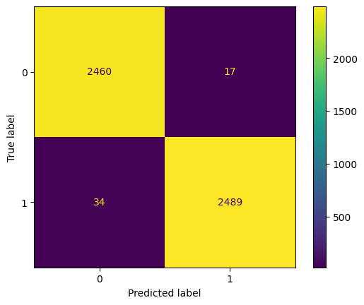

```python
# create confusion matrix
cm = confusion_matrix(y_test, xgb_cv_pred)
disp = ConfusionMatrixDisplay(confusion_matrix=cm, display_labels=None)
disp.plot()
```

```python
# Create a classification report
### YOUR CODE HERE ###
target_labels_xgb = ['0', '1']

print(classification_report(y_test, xgb_cv_pred, target_names=target_labels_xgb))
```

```
              precision    recall  f1-score   support

           0       0.99      0.99      0.99      2477
           1       0.99      0.99      0.99      2523

    accuracy                           0.99      5000
   macro avg       0.99      0.99      0.99      5000
weighted avg       0.99      0.99      0.99      5000
```

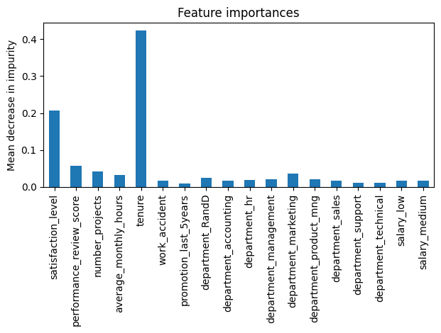

```python
importances = xgb_cv.best_estimator_.feature_importances_
rf_importances = pd.Series(importances, index=X_test.columns)

fig, ax = plt.subplots()
rf_importances.plot.bar(ax=ax)
ax.set_title('Feature importances')
ax.set_ylabel('Mean decrease in impurity')
fig.tight_layout()
```

### Conclusion, Recommendations, Next Steps

My recommendations to the company are to focus on tenure, satisfaction level, performance review score and number of projects in order to improve employee retention. The company could create incentive programs aimed at retaining employees once they hit a certain tenure and/or once their satisfaction level gets to a certain point.

As for my model, I believe the next step is to test it with more data to ensure reliability and to verify the results obtained here. Once a certain amount of time has passed, more employee data can be collected and a new model can be trained and tested to see if the most important predictive features in predicting employee turnover have changed.

**Congratulations!** You've completed this lab. However, you may not notice a green check mark next to this item on Coursera's platform. Please continue your progress regardless of the check mark. Just click on the "save" icon at the top of this notebook to ensure your work has been logged.